## 3. Répresentation cartographique des données

```r
source(paste0(wd$src,"functions/cartographie.R"))

# Graine aléatoire
set.seed(12345)
```

```r
# Importations
Total <- st_read(paste0(wd$data,"Total.shp"))
carte_bretagne <- st_read(paste0(wd$data,"masques/DepartementsOuest/LIM_ADM_DepartementsOuest.shp"))
Total <- transform_Total()
```

```r
# Carte bretagne

carte_bretagne <- carte_bretagne%>%
  st_set_crs(2154)%>%
  st_transform(4326)


# GeoNature

GN_sf <- Total %>%
  filter(bdd_originale == GN)

grid_sf <- st_sf(geometry = st_make_grid(carte_bretagne,
                                         cellsize = c(0.12, 0.09))
              )
grid_sf$density <- lengths(st_intersects(grid_sf, GN_sf))
grid_sf <- st_intersection(grid_sf, carte_bretagne)
```

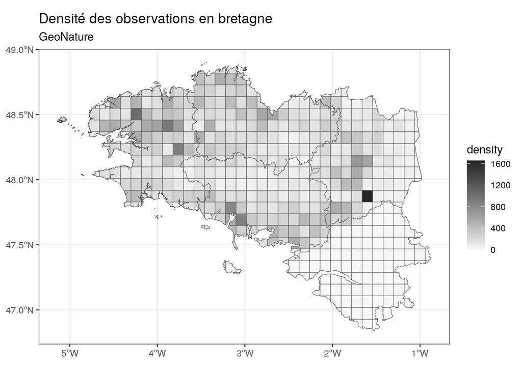

```r
ggplot() +
  geom_sf(data = carte_bretagne) +
  labs(title = "Densité des observations en bretagne",
       subtitle = GN) +
  geom_sf(data = grid_sf, aes(fill = density)) +
  scale_fill_gradient(low="gray97", high="gray15") +
  theme_bw()
```

```r
# VisioNature

VN_sf <- Total %>%
  filter(bdd_originale == VN)

grid_sf <- st_sf(geometry = st_make_grid(carte_bretagne,
                                         cellsize = c(0.12, 0.09)))
grid_sf$density <- lengths(st_intersects(grid_sf, VN_sf))
grid_sf <- st_intersection(grid_sf, carte_bretagne)
```

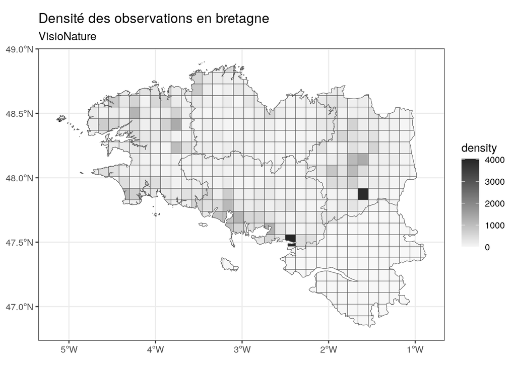

```r
ggplot() +
  geom_sf(data = carte_bretagne) +
  labs(title = "Densité des observations en bretagne",
       subtitle = VN) +
  geom_sf(data = grid_sf, aes(fill = density)) +
  scale_fill_gradient(low="grey97", high="gray15") +
  theme_bw()
```

Dans VisioNature, on a deux points avec une très forte densité sont probablement dues à nos deux principaux contributeurs (voir la partie 4), nous décidons de les supprimer pour vérifier.

```r
VN_sf_modif <- VN_sf%>%
  filter(!observateurs %in% c("BELLIER DANIEL", "CHAPUIS MARTINE"))

grid_sf <- st_sf(geometry = st_make_grid(carte_bretagne,
                                         cellsize = c(0.12, 0.09))
)
grid_sf$density <- lengths(st_intersects(grid_sf, VN_sf_modif))
grid_sf <- st_intersection(grid_sf, carte_bretagne)
```

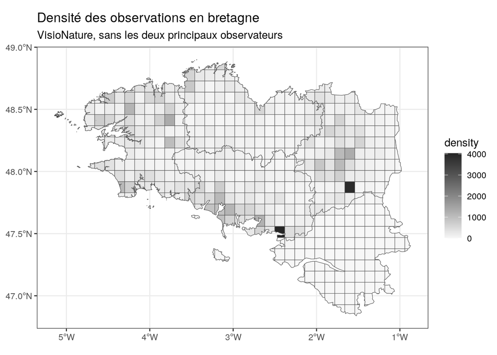

```r
ggplot() +
  geom_sf(data = carte_bretagne) +
  labs(title = "Densité des observations en bretagne",
       subtitle = "VisioNature, sans les deux principaux observateurs") +
  geom_sf(data = grid_sf, aes(fill = density)) +
  scale_fill_gradient(low="grey97", high="gray15") +
  theme_bw()
```

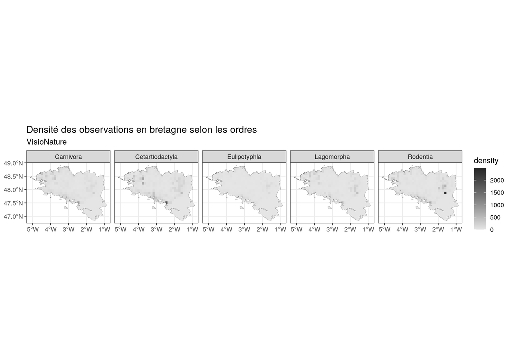

```r
# Données geographique

GN_sf <- Total%>%
  dplyr::filter(bdd_originale == GN)%>%
  dplyr::select(ordre, date)

VN_sf <- Total%>%
  dplyr::filter(bdd_originale == VN)%>%
  dplyr::select(ordre, date)

ordres <- unique(VN_sf$ordre)

grid <- st_make_grid(carte_bretagne,
                     cellsize = c(0.12, 0.09)) %>%
  st_sf() %>%
  st_set_crs(4326)

# VisioNature
grid_list <- map(ordres, function(o) {
  vis_ord <- VN_sf %>% filter(ordre == o)
  grid_tmp <- grid
  grid_tmp$density <- lengths(st_intersects(grid_tmp, vis_ord))
  grid_tmp$ordre <- o
  grid_tmp
})
grid_sf <- bind_rows(grid_list)
grid_sf <- st_intersection(grid_sf, carte_bretagne)
ggplot() +
  geom_sf(data = carte_bretagne) +
  labs(title = "Densité des observations en bretagne selon les ordres",
       subtitle = VN) +
  geom_sf(data = grid_sf, aes(fill = density), color = NA) +
  scale_fill_gradient(low="gray90", high="gray15") +
  theme_bw() +
  facet_grid(. ~ ordre)
```

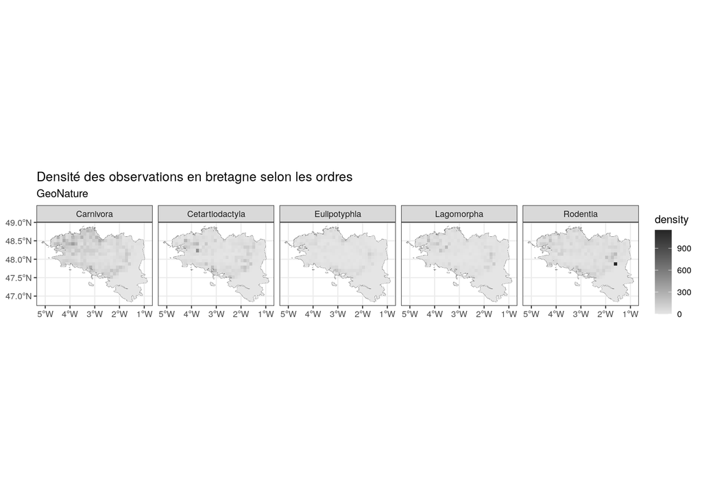

```r
# GeoNature
grid_list <- map(ordres, function(o) {
  vis_ord <- GN_sf %>% filter(ordre == o)
  grid_tmp <- grid
  grid_tmp$density <- lengths(st_intersects(grid_tmp, vis_ord))
  grid_tmp$ordre <- o
  grid_tmp
})
grid_sf <- bind_rows(grid_list)
grid_sf <- st_intersection(grid_sf, carte_bretagne)
ggplot() +
  geom_sf(data = carte_bretagne) +
  labs(title = "Densité des observations en bretagne selon les ordres",
       subtitle = "GeoNature") +
  geom_sf(data = grid_sf, aes(fill = density), color = NA) +
  scale_fill_gradient(low="gray90", high="gray15") +
  theme_bw() +
  facet_grid(. ~ ordre)
```

On ne voit pas grand chose sur la carte de VisioNature à part les 2 principaux observateurs.. Concernant la base de données GeoNature, on dirait que les espèces ont un peu près la même répartition en Bretagne (nord Finistere et Côte d’Armor et sud Ille-et-Vilaine et Morbihan)

Nous prenons la base de données avec toutes les données et je selectionne 40 000 ou 50 000 données avec les proportions.

Pour info, la graine aléatoire est figée a 12345.

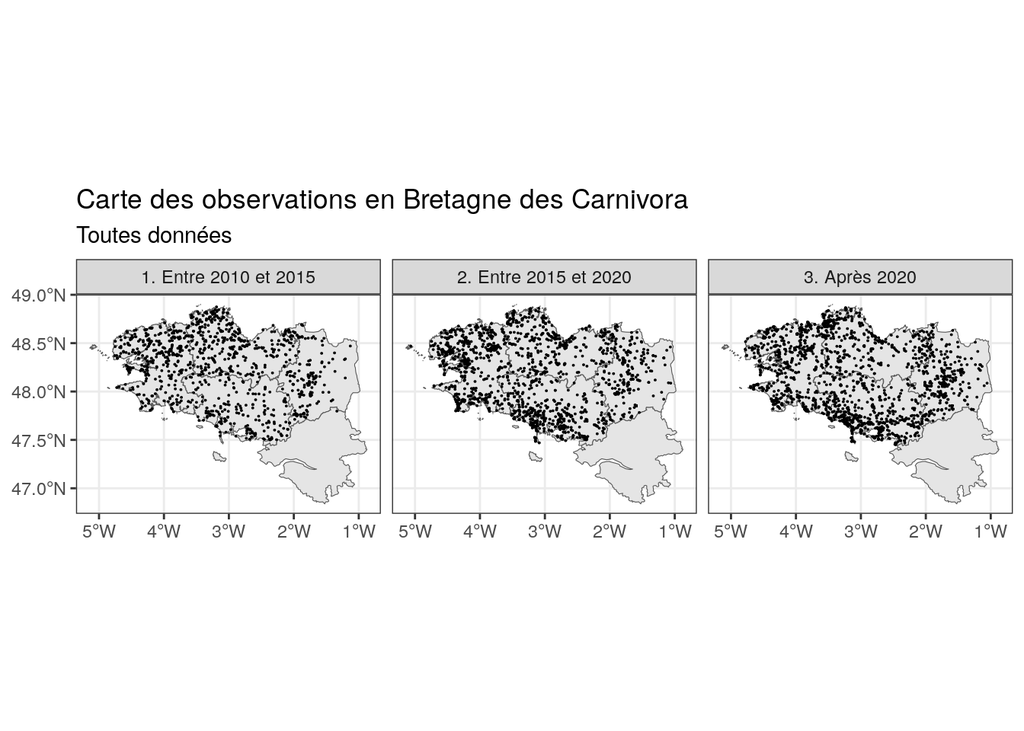

```r
graph_ordre_tranche_annee("Carnivora")
```

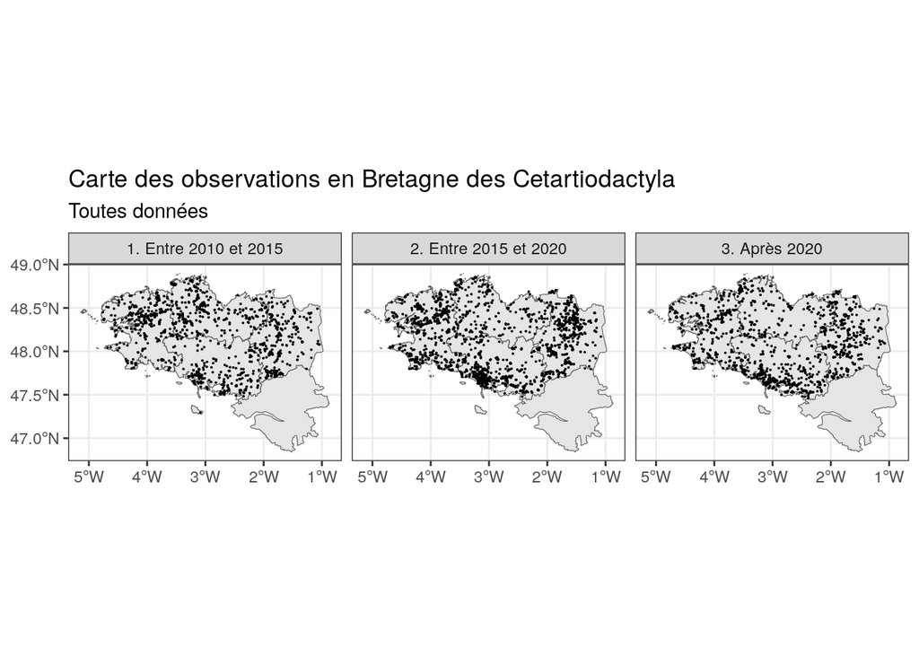

```r
graph_ordre_tranche_annee("Cetartiodactyla")
```

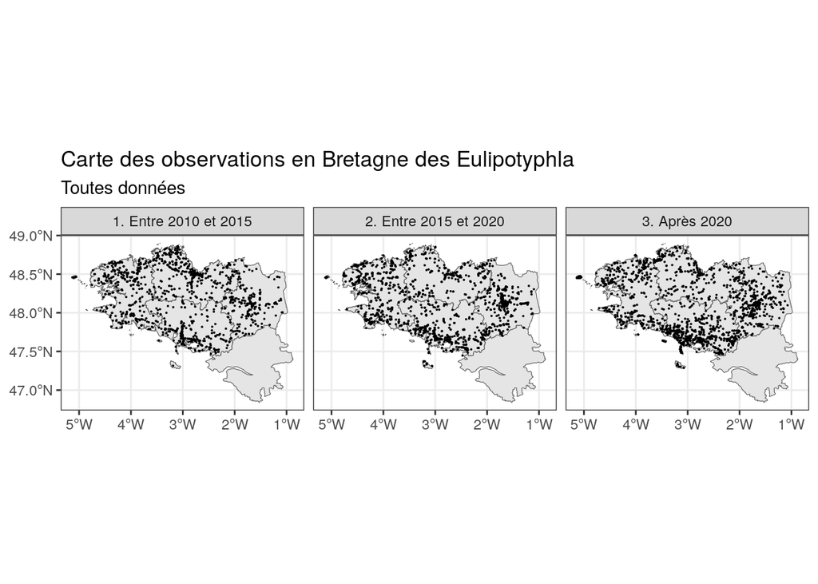

```r
graph_ordre_tranche_annee("Eulipotyphla")
```

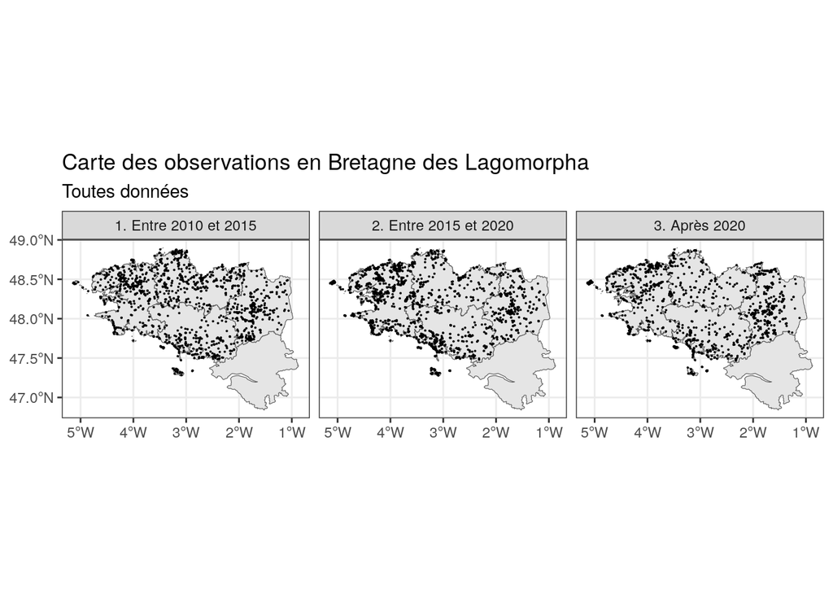

```r
graph_ordre_tranche_annee("Lagomorpha")
```

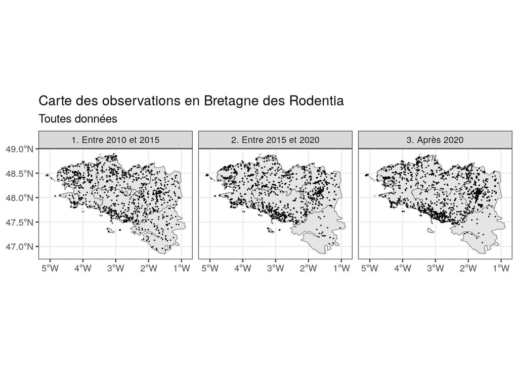

```r
graph_ordre_tranche_annee("Rodentia")
```

On dirait que plus on avance dans les années, plus on retrouve d’individus aux sud de la Bretagne. Ceci peut être car nous avons plus de données de VisioNature au fil du temps qui provient d’ornithologues et les ornithologues sont souvent proches des littoraux.